# HW 5

Broderick Prows

1/28/2020

Do the following using R. You must also turn in a copy of your R code.

1. Do opposites attract? Three Duke undergraduates conducted a study of this question in 1993. They asked questions of 28 female undergraduates concerning their own personalities. These included the following five questions: Are you 1. introverted, 2. easy-going, 3. studious, 4. serious, 5. gregarious? They asked the same five questions about the respondent’s ideal mates. Take “opposites attract” to mean that the respondent answers differently for their ideal mates than they do for themselves in at least two of the five questions. In this sample of 28, only 8 were attracted to opposites. Deeming this to be a random sample of Duke undergraduates, report and interpret in context a 90% posterior credible interval for the population proportion of those attracted to opposites. Use a beta(1, 1) prior density.

```r
prior_a <- 1
prior_b <- 1

x <- 8
n <- 28

a_star <- prior_a + x
b_star <- prior_b + n - x

Theta <- seq(0,1,length.out=1001)
posterior <- dbeta(Theta, shape1=a_star, shape2=b_star)

interval <- c(qbeta(.05,shape1=a_star,shape2=b_star), qbeta(.95,shape1=a_star,shape2=b_star))
interval
```

```
## [1] 0.1724648 0.4429359
```

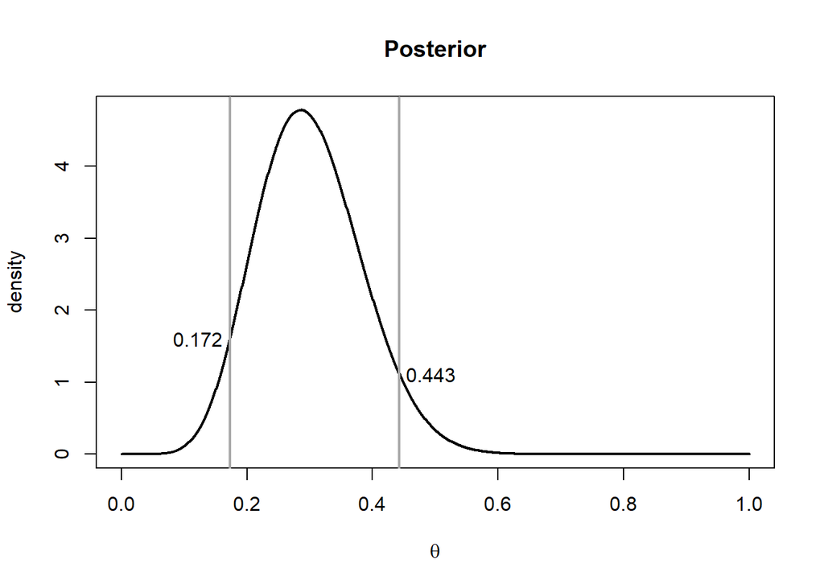

```r
plot(Theta,posterior, xlab=expression(theta),ylab='density',main='Posterior',type='l',lwd=2)
abline(v=interval,col='darkgrey',lwd=2)
text(interval[1]-.05, dbeta(interval[1],a_star,b_star), round(interval[1], 3))
text(interval[2]+.05, dbeta(interval[2],a_star,b_star), round(interval[2], 3))
```

There is a 90% probability that the true proportion of opposites attracting is between .172 and .443.

2. A study by Charles J. Graham and others at Arkansas Children’s Hospital in Little Rock addressed the question of whether left-handed children are more accident prone than right-handed children. Of 267 children between the ages of 6 and 18 who were admitted to a pediatric emergency room for trauma, 44 of them (or 16.5%) were indeed left-handed. The investigators claimed that about 10% of all children are left-handed. (Indeed, this was about the proportion of children who were admitted to the same emergency room for nontrauma reasons.) Consider the population of all pediatric trauma patients. Let θ represent the proportion of all pediatric trauma patients who are left-handed. Assume the beta(2, 18) prior density for θ.
1. For the Beta(2, 18) prior density, what is the a priori expected value of θ?

```r
prior_a <- 2
prior_b <- 18

prior_a / (prior_a + prior_b)
```

```
## [1] 0.1
```

2. Find and interpret a 95% posterior credibility interval for the population proportion of left-handers among all pediatric trauma patients.

```r
n <- 267
x <- 44

a_star <- prior_a + x
b_star <- prior_b + n - x

Theta <- seq(0,1,length.out=1001)
posterior <- dbeta(Theta, shape1=a_star, shape2=b_star)

interval <- c(qbeta(.025,shape1=a_star,shape2=b_star), qbeta(.975,shape1=a_star,shape2=b_star))
interval
```

```
## [1] 0.1202249 0.2048141
```

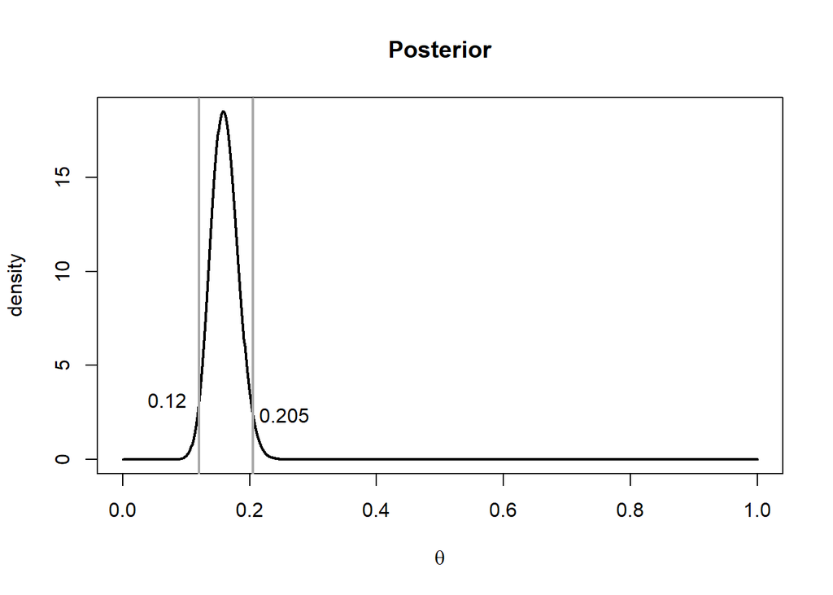

```r
plot(Theta,posterior, xlab=expression(theta),ylab='density',main='Posterior',type='l',lwd=2)
abline(v=interval,col='darkgrey',lwd=2)
text(interval[1]-.05, dbeta(interval[1],a_star,b_star), round(interval[1], 3))
text(interval[2]+.05, dbeta(interval[2],a_star,b_star), round(interval[2], 3))
```

3. Relying on the credible interval in part b, is it reasonable to claim that left-handed and right-handed children are equally accident prone, or is there substantial evidence that left-handed children are more accident prone? Explain your answer.

Since this interval does not include .10, we can conclude that left-handers are more accident prone.

4. Find the posterior probability that θ is greater than 10%.

```r
1 - pbeta(.10, shape1 = a_star, shape2 = b_star)
```

```
## [1] 0.9990954
```

5. What is the posterior expected value of θ?

```r
a_star / (a_star + b_star)
```

```
## [1] 0.1602787
```

3. In a Newsweek poll taken on February 18-19, 1993, of 753 adults who were asked, “Would you favor additional taxes to pay for reforming and expanding health care in the United States?” 65% (or 489) said “yes.” Assuming a beta(20,20) prior density, report and interpret in context a 95% credible interval for the population proportion who would have answered “yes.”

```r
prior_a <- 20
prior_b <- 20
n <- 753
x <- 489

a_star <- prior_a + x
b_star <- prior_b + n - x

Theta <- seq(0,1,length.out=1001)
posterior <- dbeta(Theta, shape1=a_star, shape2=b_star)

interval <- c(qbeta(.025,shape1=a_star,shape2=b_star), qbeta(.975,shape1=a_star,shape2=b_star))
interval
```

```
## [1] 0.6081886 0.6748663
```

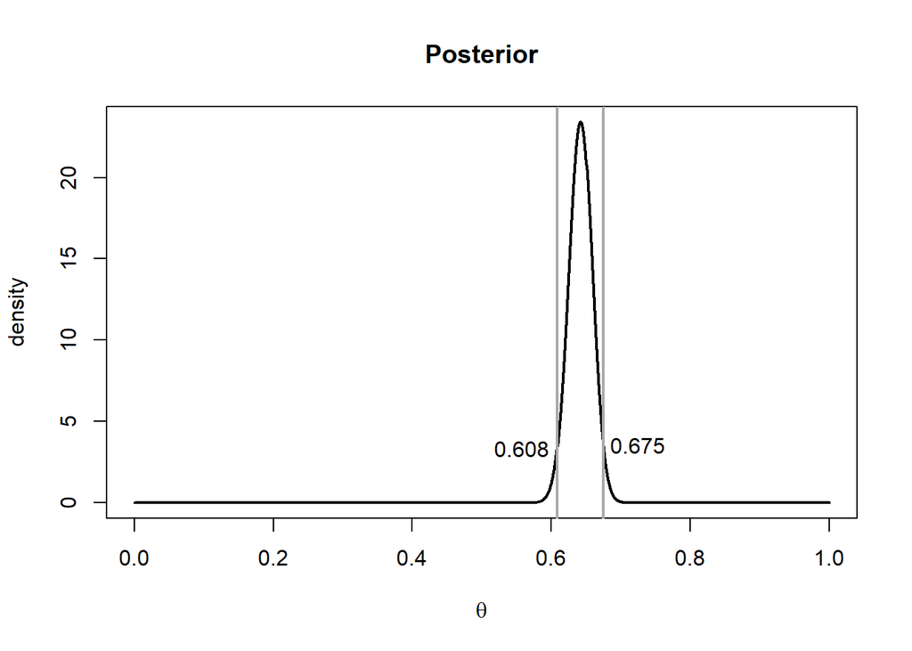

```r
plot(Theta,posterior, xlab=expression(theta),ylab='density',main='Posterior',type='l',lwd=2)
abline(v=interval,col='darkgrey',lwd=2)
text(interval[1]-.05, dbeta(interval[1],a_star,b_star), round(interval[1], 3))
text(interval[2]+.05, dbeta(interval[2],a_star,b_star), round(interval[2], 3))
```

There is a 95% probability that the true proportion of people that would have said yes to paying additional taxes for health care is between .608 and .675.

4. Repeat the previous question, but this time using a beta(1,1) prior density instead of a beta(20,20) prior density. Also comment on how sensitive the resulting intervals are to the choice of which of these two priors was used.

```r
prior_a <- 1
prior_b <- 1
n <- 753
x <- 489

a_star <- prior_a + x
b_star <- prior_b + n - x

Theta <- seq(0,1,length.out=1001)
posterior <- dbeta(Theta, shape1=a_star, shape2=b_star)

interval <- c(qbeta(.025,shape1=a_star,shape2=b_star), qbeta(.975,shape1=a_star,shape2=b_star))
interval
```

```
## [1] 0.6146217 0.6826438
```

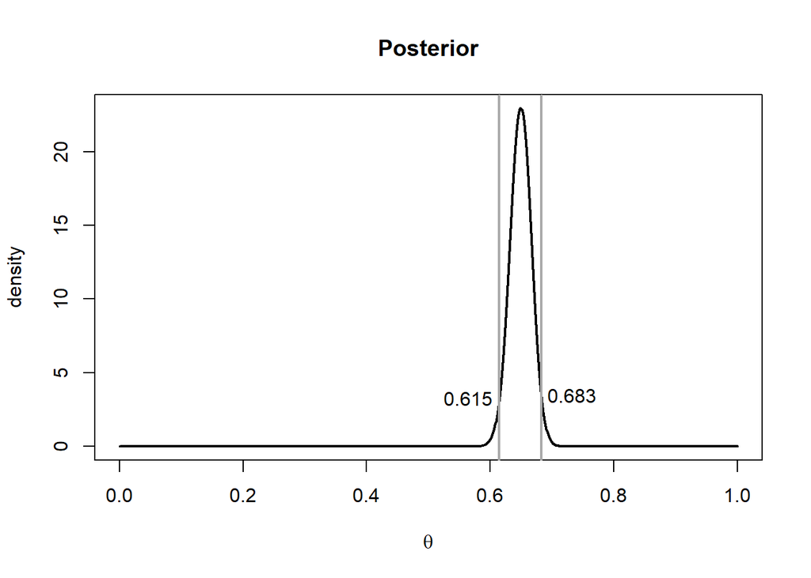

```r
plot(Theta,posterior, xlab=expression(theta),ylab='density',main='Posterior',type='l',lwd=2)
abline(v=interval,col='darkgrey',lwd=2)
text(interval[1]-.05, dbeta(interval[1],a_star,b_star), round(interval[1], 3))
text(interval[2]+.05, dbeta(interval[2],a_star,b_star), round(interval[2], 3))
```

These intervals are not very sensitive to the prior because the n is so large.

5. In a documentary film A Private Universe, only 2 of 23 gowned graduates at a Harvard University commencement were able to correctly answer the question: “Why is it hotter in summer than in winter?” In view of the results of the survey, it is difficult for me to believe that these 23 are a random sample of all Harvard graduates, but assume that they are for the sake of calculation. Assume a beta(1, 1) density for θ ≡ the proportion of Harvard graduates who would answer this question correctly.
1. What is the posterior distribution of θ?

```r
prior_a <- 1
prior_b <- 1
n <- 23
x <- 2

a_star <- prior_a + x
b_star <- prior_b + n - x

Theta <- seq(0,1,length.out=1001)
posterior <- dbeta(Theta, shape1=a_star, shape2=b_star)
```

$\theta$ ~ $Beta(3,22)$

2. Plot the prior (in gray) and the posterior (in black) densities on the same graph, and properly format this graph (including a legend to identify the prior and posterior).

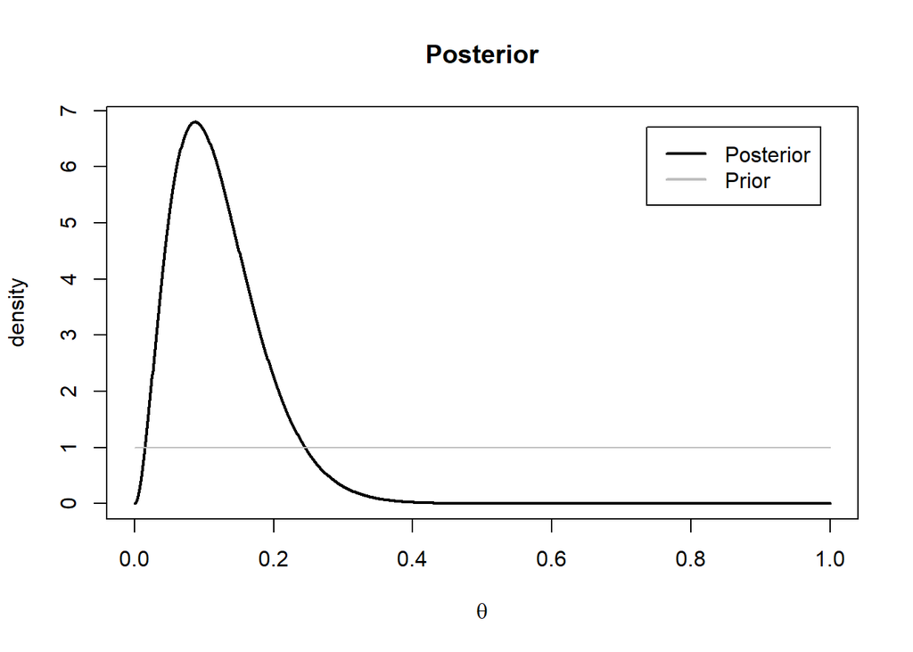

```r
plot(Theta,posterior, xlab=expression(theta),ylab='density',main='Posterior',type='l',lwd=2)
lines(Theta, dbeta(Theta, shape1=prior_a, shape2=prior_b), col = 'gray')
legend("topright", legend=c("Posterior", "Prior"),
       col=c("black", "gray"), lty = 1, lwd = 2, cex = 1, inset = .05)
```

3. Find a 99.5% (posterior) credible interval for this proportion.

```r
interval <- c(qbeta(.0025,shape1=a_star,shape2=b_star), qbeta(.9975,shape1=a_star,shape2=b_star))
interval
```

```
## [1] 0.01138949 0.35672695
```

6. For all parts of this question, you must get the answer in two ways: first, using Monte Carlo to estimate the requested quantities, and then exactly calculating the answer (using built-in R functions, if necessary). Make sure (as always) to include your R code.
1. P(Y < −13) if Y ∼ N(µ = −10, σ2 = 42).

```r
sim_vals <- rnorm(15000,mean = -10, sd = sqrt(42))
mean(sim_vals < -13)
```

```
## [1] 0.3250667
```

```r
pnorm(-13, mean = -10, sd = sqrt(42))
```

```
## [1] 0.3217144
```

2. 90% (posterior) credible interval for θ if Y |θ ∼ Binomial(42, θ), θ ∼ Beta(5.8, 7.1), and y = 19.

```r
n <- 100000
prior_a <- 5.8
prior_b <- 7.1
n <- 42
y <- 19

a_star <- prior_a + y
b_star <- prior_b + n - y

sim_theta <- rbeta(n, shape1 = a_star, shape2 = b_star)
quantile(sim_theta, c(.05, .95))
```

```
##        5%       95%
## 0.3050391 0.5434632
```

```r
Theta <- seq(0,1,length.out=1001)
posterior <- dbeta(Theta, shape1=a_star, shape2=b_star)
interval <- c(qbeta(.05,shape1=a_star,shape2=b_star), qbeta(.95,shape1=a_star,shape2=b_star))
interval
```

```
## [1] 0.3431336 0.5623459
```

3. E(X) if X ∼ Binomial(109, .63)

```r
sim_X <- rbinom(10000, size = 109, prob = .63)
mean(sim_X)
```

```
## [1] 68.6474
```

```r
109 * .63
```

```
## [1] 68.67
```